# MXN500 PST2 n10367071 MingHuai TSAI

# MXN500: Problem Solving Task 2

## Section 1: Preprocessing, data wrangling and visualisation

```r
# read library
library(tidyverse)
```

### Question 1.1

```r
# read data
df_soi_w <- read_csv("soi_data_wide.csv")
# get column names
cols_names <- names(df_soi_w)

# Remove first column which is year
cols_names <- cols_names[- 1]

# change from wide to long
df_soi <- pivot_longer(df_soi_w, cols = cols_names, names_to = "Month", values_to = "Soi")
```

```
## Note: Using an external vector in selections is ambiguous.
## i Use `all_of(cols_names)` instead of `cols_names` to silence this message.
## i See <https://tidyselect.r-lib.org/reference/faq-external-vector.html>.
```

```r
head(df_soi, 3)
```

```
## # A tibble: 3 x 3
##    Year Month   Soi
##   <dbl> <chr> <dbl>
## 1  2021 Jan    16.5
## 2  2021 Feb    11.5
## 3  2021 Mar    -0.3
```

### Question 1.2

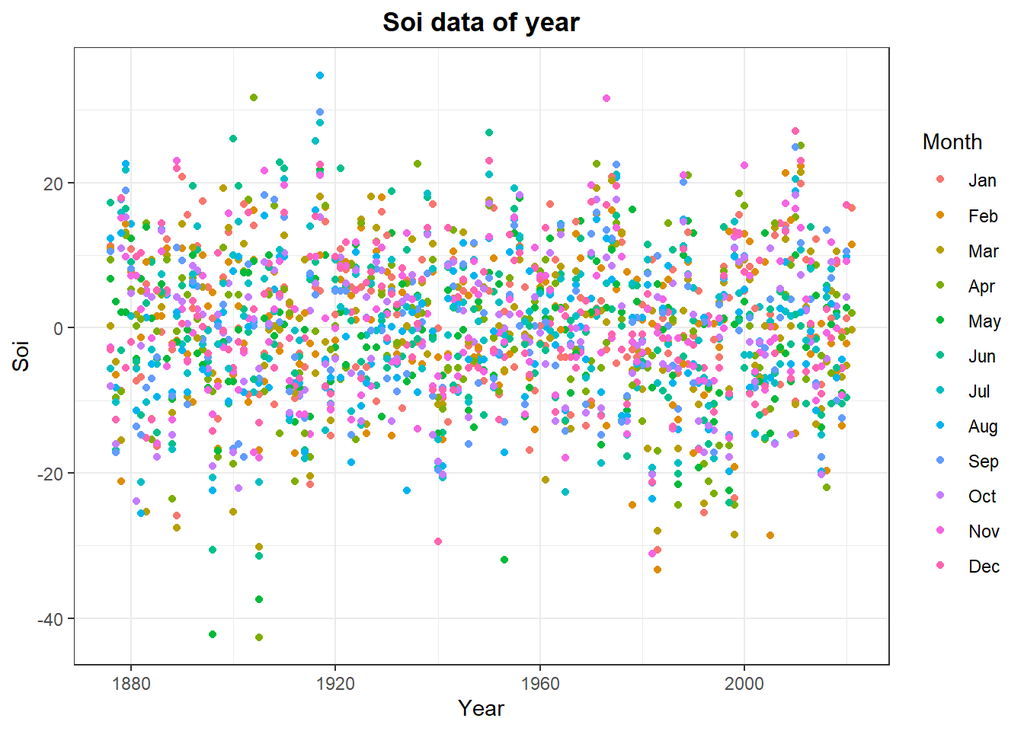

```r
month_levels <- c("Jan", "Feb", "Mar", "Apr", "May", "Jun", "Jul", "Aug", "Sep", "Oct", "Nov", "Dec")
df_soi <- mutate(df_soi, Month = factor(Month, levels = month_levels))
ggplot(data = df_soi, aes(x = Year, y = Soi)) +
  geom_point(aes(colour = factor(Month, levels = month_levels))) +
  theme_bw() +
  labs(colour = "Month",
       title = "Soi data of year") +
  theme(plot.title=element_text( hjust=0.5, face='bold'))
```

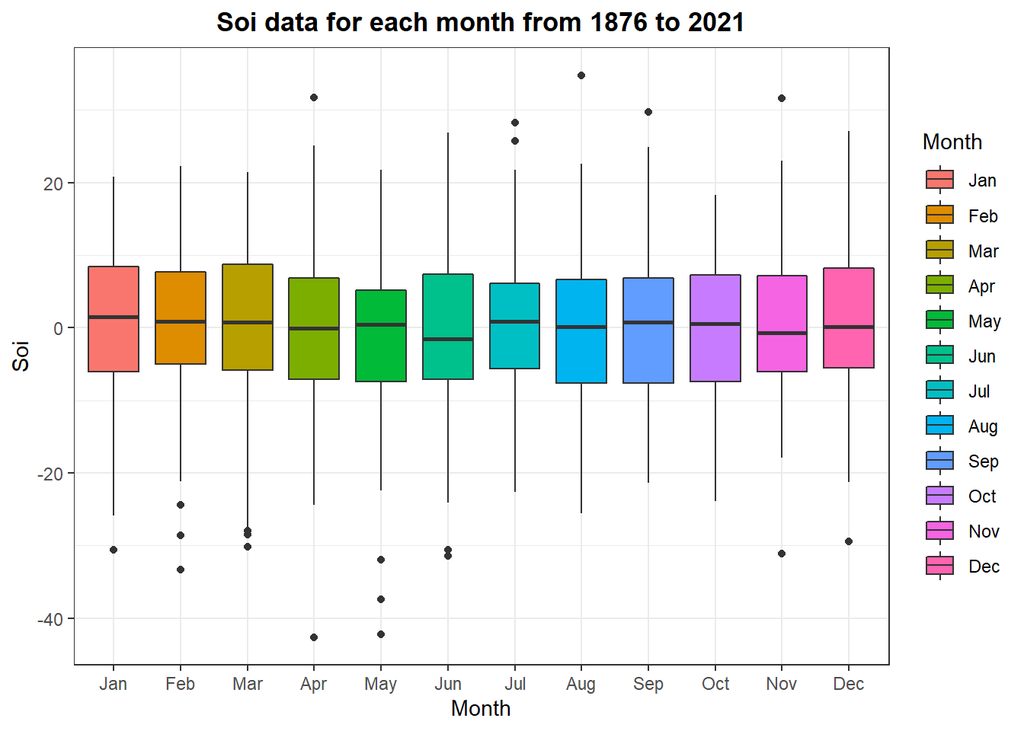

```r
month_levels <- c("Jan", "Feb", "Mar", "Apr", "May", "Jun", "Jul", "Aug", "Sep", "Oct", "Nov", "Dec")
df_soi <- mutate(df_soi, Month = factor(Month, levels = month_levels))
ggplot(data = df_soi, aes(x = Month, y = Soi)) +
  geom_boxplot(aes(fill = factor(Month, levels = month_levels))) +
  theme_bw() +
  labs(fill = "Month",
       title = "Soi data for each month from 1876 to 2021") +
  theme(plot.title=element_text( hjust=0.5, face='bold'))
```

### Question 1.3

```r
spring_months = c("Sep", "Oct", "Nov")
summer_months = c("Dec", "Jan", "Feb")
autumn_months = c("Mar", "Apr", "May")
winter_months = c("Jun", "Jul", "Aug")
seasons = c("Spring", "Summer", "Autumn", "Winter")
df_soi <- df_soi %>%
  mutate(Season = NA_character_) %>%
  mutate(Season = if_else(Month %in% summer_months, "Summer", Season)) %>%
  mutate(Season = if_else(Month %in% spring_months, "Spring", Season)) %>%
  mutate(Season = if_else(Month %in% autumn_months, "Autumn", Season)) %>%
  mutate(Season = if_else(Month %in% winter_months, "Winter", Season)) %>%
  mutate(Season = factor(Season, levels = seasons))

filter(df_soi, Year == 2020)
```

```
## # A tibble: 12 x 4
##     Year Month   Soi Season
##    <dbl> <fct> <dbl> <fct>
##  1  2020 Jan     1.3 Summer
##  2  2020 Feb    -2.2 Summer
##  3  2020 Mar    -5.2 Autumn
##  4  2020 Apr    -0.5 Autumn
##  5  2020 May     2.8 Autumn
##  6  2020 Jun    -9.6 Winter
##  7  2020 Jul     4.2 Winter
##  8  2020 Aug     9.8 Winter
##  9  2020 Sep    10.5 Spring
## 10  2020 Oct     4.2 Spring
## 11  2020 Nov     9.2 Spring
## 12  2020 Dec    16.9 Summer
```

### Question 1.4

In this question, there is a point need to be noticed. The soi value of December need to calculate with next year’s value. For example, value in 2020 December need to calculate with 2021 January and 2021 February. In this situation, we are going to create fake years for December, the fake year will be the original year plus 1. For example 2020 will be transform to 2021.

```r
df_soi <- mutate(df_soi, Year_fake = if_else(Month == "Dec", Year+1, Year))
filter(df_soi, Year == 2020)
```

```
## # A tibble: 12 x 5
##     Year Month   Soi Season Year_fake
##    <dbl> <fct> <dbl> <fct>      <dbl>
##  1  2020 Jan     1.3 Summer      2020
##  2  2020 Feb    -2.2 Summer      2020
##  3  2020 Mar    -5.2 Autumn      2020
##  4  2020 Apr    -0.5 Autumn      2020
##  5  2020 May     2.8 Autumn      2020
##  6  2020 Jun    -9.6 Winter      2020
##  7  2020 Jul     4.2 Winter      2020
##  8  2020 Aug     9.8 Winter      2020
##  9  2020 Sep    10.5 Spring      2020
## 10  2020 Oct     4.2 Spring      2020
## 11  2020 Nov     9.2 Spring      2020
## 12  2020 Dec    16.9 Summer      2021
```

Then, we are going to use fake year to calculate the mean of soi in each season.

```r
seasonal_soi_values <- df_soi %>%
  group_by(Year_fake, Season) %>%
  summarise(SeasonalSOI = mean(Soi, na.rm = T)) %>%
  rename(Year = Year_fake) # Rename Year_fake to Year
filter(seasonal_soi_values, Year == 2020)
```

```
## # A tibble: 4 x 3
## # Groups:   Year [1]
##    Year Season SeasonalSOI
##   <dbl> <fct>        <dbl>
## 1  2020 Spring       7.97
## 2  2020 Summer      -2.13
## 3  2020 Autumn      -0.967
## 4  2020 Winter       1.47
```

### Question 1.5

```r
seasonal_soi_values <- seasonal_soi_values %>%
  mutate(Phase = "Neutral") %>%
  mutate(Phase = if_else(SeasonalSOI > 8, "LaNina", Phase)) %>%
  mutate(Phase = if_else(SeasonalSOI < -8, "ElNino", Phase))

filter(seasonal_soi_values, Year == 2011)
```

```
## # A tibble: 4 x 4
## # Groups:   Year [1]
##    Year Season SeasonalSOI Phase
##   <dbl> <fct>        <dbl> <chr>
## 1  2011 Spring       10.9  LaNina
## 2  2011 Summer       23.1  LaNina
## 3  2011 Autumn       16.2  LaNina
## 4  2011 Winter        4.33 Neutral
```

### Question 1.6

```r
seasons = c("Spring", "Summer", "Autumn", "Winter")
phases = c("LaNina", "Neutral", "ElNino")
seasonal_soi_values <- seasonal_soi_values %>%
  mutate(Season = factor(Season, levels = seasons)) %>%
  mutate(Phase = factor(Phase, levels = phases))

levels(seasonal_soi_values$Season)
```

```
## [1] "Spring" "Summer" "Autumn" "Winter"
```

```r
levels(seasonal_soi_values$Phase)
```

```
## [1] "LaNina"  "Neutral" "ElNino"
```

## Section 2: Linear Regression

### Set up

```r
total_seasonal_rainfall <- read_csv("total_seasonal_rainfall.csv") %>%
  mutate(total_seas_prcp = total_seas_prcp/10) %>%
  left_join(seasonal_soi_values)
```

### Question 2.1

For the Brisbane Station in Spring, a linear model was specified to model how the total seasonal precipitation, $y_{i}$, is related to the mean seasonal SOI value, $x_{i}$.

The parameter $\beta_{1}$ describes the rate of change in the total seasonal precipitation with an increase in mean seasonal SOI value.

### Question 2.2

The equation is $\hat{y} = 222.199+3.68x$

```r
# generate the data
brisbane_spring <- total_seasonal_rainfall %>%
  filter(name == "BRISBANE REGIONAL OFFICE" & Season == "Spring")

brisbane_spring_lm <- lm(data = brisbane_spring, total_seas_prcp ~ SeasonalSOI)

summary(brisbane_spring_lm)
```

```
##
## Call:
## lm(formula = total_seas_prcp ~ SeasonalSOI, data = brisbane_spring)
##
## Residuals:
##     Min      1Q  Median      3Q     Max
## -188.72  -82.69  -15.65   52.31  471.54
##
## Coefficients:
##             Estimate Std. Error t value Pr(>|t|)
## (Intercept)  222.199     12.427  17.880   <2e-16 ***
## SeasonalSOI    3.680      1.428   2.578   0.0117 *
## ---
## Signif. codes:  0 '***' 0.001 '**' 0.01 '*' 0.05 '.' 0.1 ' ' 1
##
## Residual standard error: 113.9 on 82 degrees of freedom
##   (26 observations deleted due to missingness)
## Multiple R-squared:  0.07495,    Adjusted R-squared:  0.06367
## F-statistic: 6.644 on 1 and 82 DF,  p-value: 0.01174
```